# Analysis on Jail Populations in the U.S.

Maya Shukla

2022-11-21

## Abstract

My main question when looking at this data set and reading more about mass incarceration in the United States is how disproportionately are black men arrested in comparison to white men.

## Introduction

During Ronald Reagan’s presidency, he instated a new policy on drug related policing. He coined it “The War on Drugs.” Unfortunately, this did not have the outcome he desired. It increased incarceration rates immensely and disproportionately targeted neighborhoods of minorities and people of color. By passing legislation to arrest people for minor possessions and consumption of drugs mainly present in minority neighborhoods, the population of people of color in jails increased exponentially. Due to an increasing prison population and increase in police activity, police brutality is also on the rise as they are first responders for all calls and have weapons that can inflict a lot of damage. Police brutality has also increased exponentially due to inherent biases and racism. Minority populations and people of color live in fear and act extremely wary around police officials, even though police are supposed to protect. With an excess of funding and support, law enforcement is still being excessively rough and violent to people of color, mainly black individuals. In my report, I will be comparing the prison population of black and white men in the 1970s and today. This will show the drastic effect that the War on Drugs had.

## Data Summary

In 2000 there was an average of 326.94 black male inmates in the U.S. jail system, the highest average number between 1970 and 2018. In the same year there were 231.92 white male inmates. The difference is very large and shows the disproportionate amount of black men arrested as opposed to white men. In 2010 there was an average of 275.56 white male inmates, the highest average between 1970 and 2018. In that year, there were 314.85 male black inmates. Even at the *highest average white male* jail population, *average black male jail population* is **still** higher. In 1998 the difference between male white and black inmates was 126.17. The difference between black and white inmates is almost the same amount as the amount of white inmates that year. That shows that in 1998 a black man is **two times** more likely to end up in jail compared to a white man. Every single year from 1970 and 2018 shows that there is a higher average of black men in jail compared to white men in jail. This highlights the disproportionate policing in black versus white neighborhoods. By looking at the difference between black and white male jail populations, we are able to see a pattern of inequality between black and white men.

## Chart showing the Increase in Jail Population in the U.S. from 1970-2018.

[output not shown]

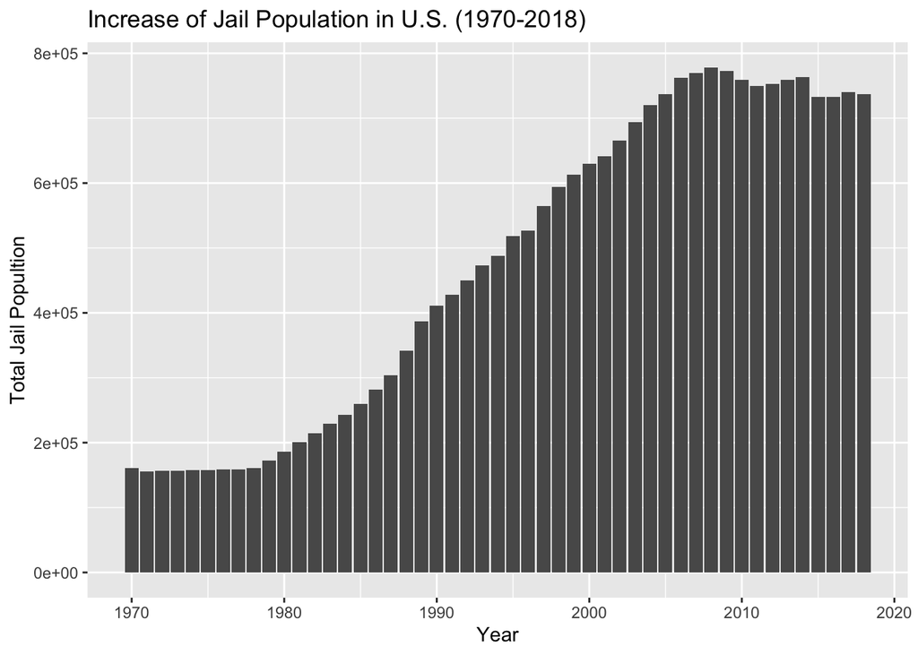

This chart’s purpose is to visualize how jail populations have increase since 1970. After the War on Drugs began, jail populations increased exponentially. Over the years more and more people were sentenced to jail. At the same time, people were already in jail serving long sentences for minor crimes. Stricter policing has lead to an increase in jail populations.

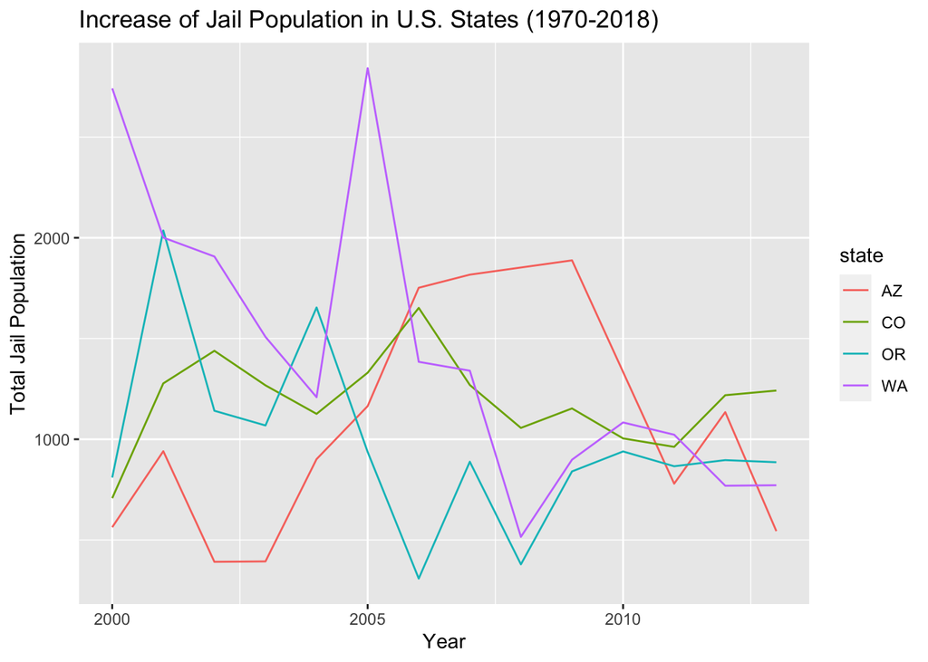

## Chart showing the difference between Black and White Jail Population.

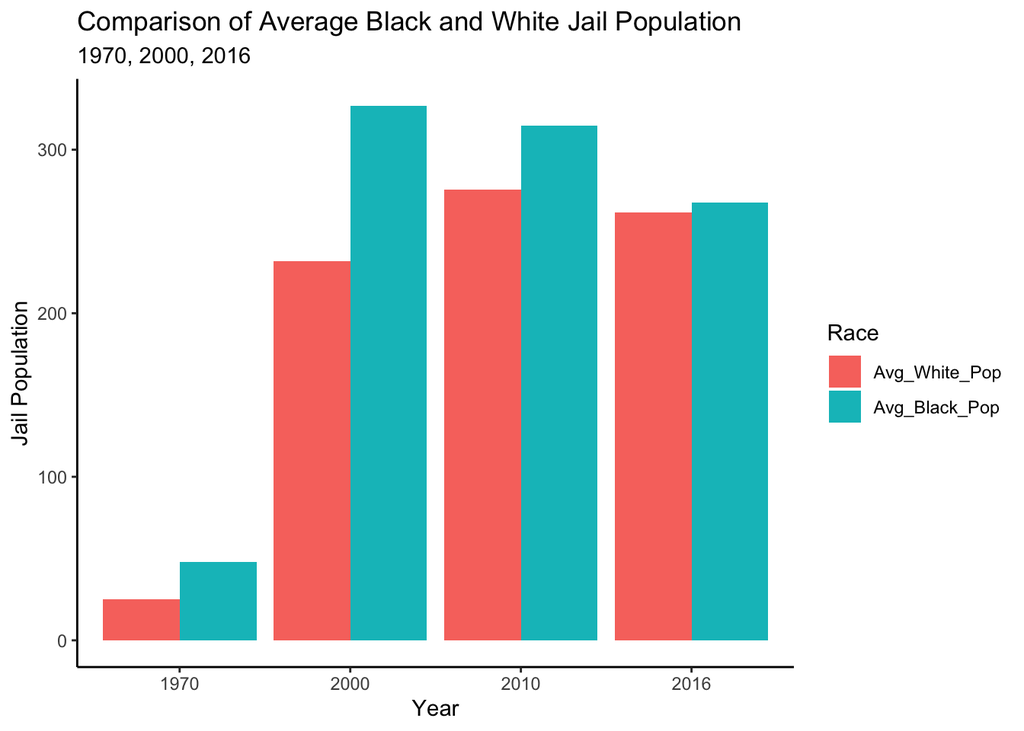

This chart shows disproportionate jailing between Black men and White men. The highest average black man jail population was in 2000 at 326.94. The highest average white man jail population was in 2010 at 275.6. This chart shows a pattern of inequality because in each year displayed on the chart, black jail population is always higher than white jail population. Even the highest white population was lower than the black population in the same year.

## Chart showing the difference between jail populations in each state.

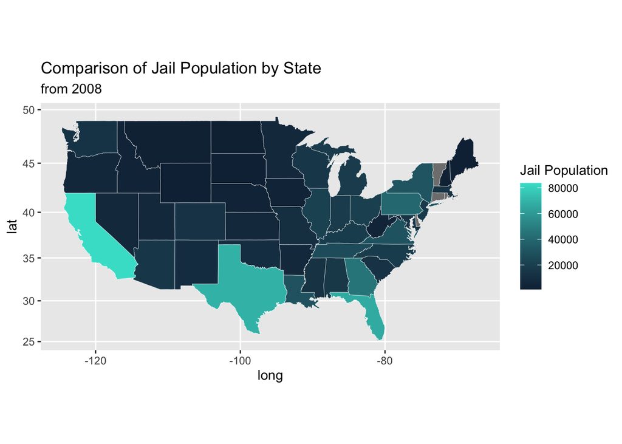

This chart shows the jail populations between states in 2008. It is analyzing 2008 since that was the year with the highest jail population. The states with the highest jail populations are California, Texas, and Florida. These are also the three most populous states in the US. All three states also have a high population of people of color. The next state that has a high jail population is Georgia, which has a high black population. These are indicators that there is disproportionate jailing of people of color in the United States.